# Best Practice in Python QuantStrategy, Backtesting, and Live Trading: Quantopian

李宜熹

eclee@nkfust.edu.tw

2016-11-15 & 2016-11-22

教材下載

## [https://github.com/eclee/Quantopian](https://github.com/eclee/Quantopian)

## 教材使用說明

- Terminal (CMD)：安裝 jupyter notebook 的 [RISE 套件](https://github.com/damianavila/RISE) `conda install -c damianavila82 rise`
- 啟動 jupyter notebook
  - 搜尋 jupyter notebook => 左鍵點擊 jupyter notebook
- 讓 jupyter notebook 可以輸出多執行結果

  ```
  from IPython.core.interactiveshell import InteractiveShell
  InteractiveShell.ast_node_interactivity = "all"
  ```

## 大綱

- 開始之前：
  - 市場效率性
  - 大數據時代
- 最佳實務：Quantopian Platform / zipline
  - 影領當下華爾街量化投資的最佳實務
- 動手實作
  - Quantopian Algorithms (Backtest)
  - Quantopian Notebooks (Research)
  - zipline (Quantopian 的開源版本)

## 市場：效率 vs. 無效率

[figure not shown]

## 市場：效率 vs. 無效率 (挑戰者號太空梭 1986)

[figure not shown]

## 市場：效率 vs. 無效率

[figure not shown]

## 大數據 (多元數據) 議題：Google Trends

[figure not shown]

## 資料源：[Sentdex: Quantitifing the Qualitative](http://sentdex.com/)

[figure not shown]

## 小結

- 啟思 1：量化投資與程式交易是個高手輩出的應用領域
  - 最先進的科技通常應用在兩個領域：戰爭 & 金融！
- 啟思 2：大數據的年代
  - 4Vs 大、快、雜、疑

## Quant. Trading 涉及的議題

- 資料源 (正確性、即時性、廣泛性)
- 運算力 (運算速度、程式彈性、重複利用)
- 下單源 (API 下單)
- 支援性 (疑難雜症的解決)
- 隱匿性 (智財權不會被竊取)

## [stockfeel 專欄報導：Quantopian 演算法交易平台](https://www.stockfeel.com.tw/%E5%85%A8%E7%90%83%E9%A0%98%E5%85%88%E7%9A%84python%E6%BC%94%E7%AE%97%E6%B3%95%E4%BA%A4%E6%98%93%E5%B9%B3%E5%8F%B0%E2%94%80quantopian/)

[figure not shown]

## WEF (2015), The Future of Financial Servies, p.134

[figure not shown]

## [MIC 與 Fugle 合開的開課資訊：Quantopian 教學](http://mic.iii.org.tw/Institute/course/recent_ins.aspx?sqno=1585) (新台幣：6500)

[figure not shown]

## [Quantopian](https://www.quantopian.com/) 官方指引

- [Quantopian 量化策略搜尋：Quantopian => Community => Forum](https://www.quantopian.com/posts)
- Quantopian 官網線上教學
  - Python Basics
    - [Lecture 2: Introduction to PythonSome basic tools for working in the language](https://www.quantopian.com/lectures#Introduction-to-Python)
    - [Lecture 3: Introduction to NumPyHow to use NumPy for computing on data](https://www.quantopian.com/lectures#Introduction-to-NumPy)
    - [Lecture 4: Introduction to pandas An introduction to using pandas to manage and analyze your data](https://www.quantopian.com/lectures#Introduction-to-pandas)
    - [Lecture 5: Plotting DataA brief primer](https://www.quantopian.com/lectures#Plotting-Data)
  - [Quantopian Overview](https://www.quantopian.com/help)
  - [Tutorials: Getting Started](https://www.quantopian.com/tutorials/getting-started)
  - [Tutorials: pipeline](https://www.quantopian.com/tutorials/pipeline)
  - [Lectures](https://www.quantopian.com/lectures)
  - [FAQ](https://www.quantopian.com/faq)
- [Quantopian 官方 Youtube](https://www.youtube.com/channel/UC606MUq45P3zFLa4VGKbxsg)
- [Quantopian Github](https://github.com/quantopian)
  - zipline (Quantopian 的開源版)
    - [zipline 教學指引](http://www.zipline.io/#quickstart)

## [Quantopian](https://www.quantopian.com/)

[figure not shown]

## 我的第一個 Quantopian 量化策略與回溯測試

- 註冊與登入帳號：[Quantopian](https://www.quantopian.com/)
- [量化策略搜尋：Quantopian => Menu => Community => Forum => Search => Clone Algorithm](https://www.quantopian.com/posts)
  - 搜尋有興趣的量化策略
    - [常見的技術指標](http://ta-lib.org/function.html) (<= 如果不清楚想要找什麼或不知道技術指標的英文，可以點這裡查閱)
    - [Sample Mean Reversion Algorithm](https://www.quantopian.com/posts/sample-mean-reversion-algorithm-hello-world)
    - [Long/Short trading strategy with WSJ, Forbes, and CNBC News sentiment](https://www.quantopian.com/posts/long-slash-short-trading-strategy-with-wsj-forbes-and-cnbc-news-sentiment)
    - [Seeking Feedback on Trading based on Sentiment Analysis + Intro](https://www.quantopian.com/posts/seeking-feedback-on-trading-based-on-sentiment-analysis-plus-intro)
    - [Sentdex Sentiment Signals for Finance](http://sentdex.com/api/finance/sentiment-signals/sample/')
  - 官網範例：Quantopian Overview - Sample Algorithms)
- [量化策略回測：Quantopian => Menu => My Code => Algorithms => Click the specific Algorhtm => Run Full Backtest](https://www.quantopian.com/algorithms)

[figure not shown]

## Quantopian 指引

- [Tutorials: Getting Started](https://www.quantopian.com/tutorials/getting-started)
- [Tutorials: pipeline](https://www.quantopian.com/tutorials/pipeline)

[figure not shown]

## Quantopian 指引：[Tutorials: Getting Started](https://www.quantopian.com/tutorials/getting-started)

[figure not shown]

## [Quantopina => Algorithms](https://www.quantopian.com/algorithms)

[figure not shown]

## [整合實例：Algorithms](https://www.quantopian.com/tutorials/getting-started#lesson11)

- Sample Code ([將下列程式碼放入 Quantopian => Menu => My Code => Algorithms => ...](https://www.quantopian.com/algorithms))

```
def initialize(context):
    """
    initialize() is called once at the start of the program. Any one-time
    startup logic goes here.
    """
```

```
# An assortment of securities from different sectors:
# MSFT, UNH, CTAS, JNS, COG
context.security_list = [sid(5061), sid(7792), sid(1941), sid(24556), sid(1746)]

# Rebalance every Monday (or the first trading day if it's a holiday)
# at market open.
schedule_function(rebalance,
                  date_rules.week_start(days_offset=0),
                  time_rules.market_open())

# Record variables at the end of each day.
schedule_function(record_vars,
                  date_rules.every_day(),
                  time_rules.market_close())
```

def compute_weights(context, data): """ Compute weights for each security that we want to order. """

```
# Get the 30-day price history for each security in our list.
hist = data.history(context.security_list, 'price', 30, '1d')

# Create 10-day and 30-day trailing windows.
prices_10 = hist[-10:]
prices_30 = hist

# 10-day and 30-day simple moving average (SMA)
sma_10 = prices_10.mean()
sma_30 = prices_30.mean()

# Weights are based on the relative difference between the short and long SMAs
raw_weights = (sma_30 - sma_10) / sma_30

# Normalize our weights
normalized_weights = raw_weights / raw_weights.abs().sum()

# Determine and log our long and short positions.
short_secs = normalized_weights.index[normalized_weights < 0]
long_secs = normalized_weights.index[normalized_weights > 0]

log.info("This week's longs: " + ", ".join([long_.symbol for long_ in long_secs]))
log.info("This week's shorts: " + ", ".join([short_.symbol for short_ in short_secs]))

# Return our normalized weights. These will be used when placing orders later.
return normalized_weights
```

def rebalance(context, data): """ This function is called according to our schedule_function settings and calls order_target_percent() on every security in weights. """

```
# Calculate our target weights.
weights = compute_weights(context, data)

# Place orders for each of our securities.
for security in context.security_list:
    if data.can_trade(security):
        order_target_percent(security, weights[security])
```

def record_vars(context, data): """ This function is called at the end of each day and plots our leverage as well as the number of long and short positions we are holding. """

```
# Check how many long and short positions we have.
longs = shorts = 0
for position in context.portfolio.positions.itervalues():
    if position.amount > 0:
        longs += 1
    elif position.amount < 0:
        shorts += 1

# Record our variables.
record(leverage=context.account.leverage, long_count=longs, short_count=shorts)
```

## Backtest: Results Overieves

[figure not shown]

## Backtest: Transaction Details

[figure not shown]

## Backtest: Daily Positions & Gains

[figure not shown]

## Backtest: Log Output

[figure not shown]

## Backtest: Risk Metrics - Max Drawdown

[figure not shown]

## Quantopian Overview: Sample Algorithms)

[figure not shown]

# 實例演練：[Quantopina => Algorithms](https://www.quantopian.com/algorithms)

- [量化策略搜尋：Quantopian => Menu => Community => Forum => Search => Clone Algorithm](https://www.quantopian.com/posts)
  - 搜尋有興趣的量化策略
    - [常見的技術指標](http://ta-lib.org/function.html) (<= 如果不清楚想要找什麼或不知道技術指標的英文，可以點這裡查閱)
    - [Sample Mean Reversion Algorithm](https://www.quantopian.com/posts/sample-mean-reversion-algorithm-hello-world)
    - [Long/Short trading strategy with WSJ, Forbes, and CNBC News sentiment](https://www.quantopian.com/posts/long-slash-short-trading-strategy-with-wsj-forbes-and-cnbc-news-sentiment)
    - [Seeking Feedback on Trading based on Sentiment Analysis + Intro](https://www.quantopian.com/posts/seeking-feedback-on-trading-based-on-sentiment-analysis-plus-intro)
- 官網範例：Quantopian Overview - Sample Algorithms
- 量化策略回測：Quantopian => Menu => My Code => Algorithms => Click the specific Algorhtm => Run Full Backtest
- 疑難排除
  - https://www.quantopian.com/help

## [Quantopian Research Platform (Notebooks / Pipeline)](https://www.quantopian.com/research)

[Quantopian => Menu => My Code => Notebooks => ...](https://www.quantopian.com/research)

[figure not shown]

## [Quantopian Research Platform (Notebooks / Pipeline)](https://www.quantopian.com/research)

[Quantopian => Menu => My Code => Notebooks => ...](https://www.quantopian.com/research)

[figure not shown]

## Sample Codes:

- get_pricing()

  ```
  aapl_minute_closes = get_pricing(
    'BABA',
    fields='close_price', #modify to price, open_price, high, low or volume to change the field
    start_date='2015-1-1', #customize your pricing date range
    end_date = '2016-11-14',
    frequency='minute', #change to daily for daily pricing
  )
  aapl_minute_closes.plot() # matplotlib is installed for easy plotting
  ```

- get_backtest()

  ```
  result = get_backtest('536a6d181a4f090716c383b7')
  result.preview('risk')
  ```

- local_csv()

  ```
  AAPLRev = local_csv('AAPL_Rev.csv', date_column = 'Date', use_date_column_as_index = True)  # Apple_Rev is a CSV from Quandl showing the quarterly revenue for Apple.
  AAPLRev.plot()
  ```

## 資料源：[Quandl](https://www.quandl.com/)：支援多種程式語言

[figure not shown]

## 資料源：[Quandl](https://www.quandl.com/)：包含許多報價資料 (免費 / 付費)

[figure not shown]

## [整合實例：Notebooks](https://www.quantopian.com/tutorials/pipeline#lesson11)

- Sample Code ([將下列程式碼放入 Quantopian => Menu => My Code => Notebooks => ...](https://www.quantopian.com/research))
  - 引入套件、模組與函式 `# https://www.quantopian.com/tutorials/pipeline#lesson11`

    ```
      from quantopian.pipeline.data import morningstar
      from quantopian.pipeline.filters.morningstar import IsPrimaryShare
      from quantopian.pipeline import Pipeline
      from quantopian.pipeline import CustomFactor
      from quantopian.research import run_pipeline
      from quantopian.pipeline.data.builtin import USEquityPricing

      from quantopian.pipeline.factors import AverageDollarVolume, SimpleMovingAverage
         # https://www.quantopian.com/help#masking-factors
    ```

## [整合實例：Notebooks](https://www.quantopian.com/tutorials/pipeline#lesson11)

- Sample Code ([將下列程式碼放入 Quantopian => Menu => My Code => Notebooks => ...](https://www.quantopian.com/research))
  - 自訂 make_pipeline() 函式

    ```
      def make_pipeline():

      # Filter for primary share equities. IsPrimaryShare is a built-in filter.
      primary_share = IsPrimaryShare()

      # Equities listed as common stock (as opposed to, say, preferred stock).
      # 'ST00000001' indicates common stock.
      common_stock = morningstar.share_class_reference.security_type.latest.eq('ST00000001')

      # Non-depositary receipts. Recall that the ~ operator inverts filters,
      # turning Trues into Falses and vice versa
      not_depositary = ~morningstar.share_class_reference.is_depositary_receipt.latest

      # Equities not trading over-the-counter.
      not_otc = ~morningstar.share_class_reference.exchange_id.latest.startswith('OTC')

      # Not when-issued equities.
      not_wi = ~morningstar.share_class_reference.symbol.latest.endswith('.WI')

      # Equities without LP in their name, .matches does a match using a regular
      # expression
      not_lp_name = ~morningstar.company_reference.standard_name.latest.matches('.* L[. ]?P.?$')

      # Equities with a null value in the limited_partnership Morningstar
      # fundamental field.
      not_lp_balance_sheet = morningstar.balance_sheet.limited_partnership.latest.isnull()

      # Equities whose most recent Morningstar market cap is not null have
      # fundamental data and therefore are not ETFs.
      have_market_cap = morningstar.valuation.market_cap.latest.notnull()

      # Filter for stocks that pass all of our previous filters.
      tradeable_stocks = (
          primary_share
          & common_stock
          & not_depositary
          & not_otc
          & not_wi
          & not_lp_name
          & not_lp_balance_sheet
          & have_market_cap
      )

      # Base universe filter.
      base_universe = AverageDollarVolume(window_length=20, mask=tradeable_stocks).percentile_between(70, 100)

      # 10-day close price average.
      mean_10 = SimpleMovingAverage(inputs=[USEquityPricing.close], window_length=10, mask=base_universe)

      # 30-day close price average.
      mean_30 = SimpleMovingAverage(inputs=[USEquityPricing.close], window_length=30, mask=base_universe)

      # Percent difference factor.
      percent_difference = (mean_10 - mean_30) / mean_30

      # Create a filter to select securities to short.
      shorts = percent_difference.top(25)

      # Create a filter to select securities to long.
      longs = percent_difference.bottom(25)

      # Filter for the securities that we want to trade.
      securities_to_trade = (shorts | longs)

      return Pipeline(
        columns={
          'longs': longs,
          'shorts': shorts
        },
        screen=securities_to_trade
      )
    ```

## [整合實例：Notebooks](https://www.quantopian.com/tutorials/pipeline#lesson11)

- Sample Code ([將下列程式碼放入 Quantopian => Menu => My Code => Notebooks => ...](https://www.quantopian.com/research))
  - 執行 pipeline (使用 run_pipeline() 函式)

    ```
      result = run_pipeline(make_pipeline(), '2015-05-05', '2015-05-05')
      result.head()

## Quantopian Overview: Research Environment API

[figure not shown]

## [Quantopian Overview](https://www.quantopian.com/help)

[figure not shown]

# 實例演練：[Quantopina => Notebooks](https://www.quantopian.com/research)

- [量化策略搜尋：Quantopian => Menu => Community => Forum => Search => Clone Notebook](https://www.quantopian.com/posts)
  - 搜尋有興趣的量化策略
    - [常見的技術指標](http://ta-lib.org/function.html) (<= 如果不清楚想要找什麼或不知道技術指標的英文，可以點這裡查閱)
    - [Generalized Method of Moments with ARCH and GARCH Models](https://www.quantopian.com/posts/quantopian-lecture-series-arch-garch-and-gmm)
    - ...
- [官網範例：Quantopian Overview - Research Environment API](https://www.quantopian.com/help#research-env)
- 疑難排除：
  - https://www.quantopian.com/help

## [Quantopian 的開源版：zipline](https://github.com/quantopian/zipline) ([線上教學指引](http://www.zipline.io/#quickstart))

[figure not shown]

# [Introduction to Zipline](http://www.zipline.io/)

## Features

- Ease of use: Developed and continuously updated by Quantopian which provides an easy-to-use web-interface to Zipline. It tries to get out of your way so that you can focus on algorithm development.
- Realistic: slippage, transaction costs, order delays.
- Stream-based: Process each event individually, avoids look-ahead bias.
- Batteries included: Common transforms (moving average) as well as common risk calculations (Sharpe).

## [Install (Terminal)](http://www.zipline.io/install.html#installing-with-pip)

`pip install zipline`

# [zipline 基本結構](http://www.zipline.io/beginner-tutorial.html#my-first-algorithm)

- Every zipline algorithm consists of two functions you have to define:
  - initialize(context)
  - handle_data(context, data)
- Before the start of the algorithm, zipline calls the initialize() function and passes in a context variable. context is a persistent namespace for you to store variables you need to access from one algorithm iteration to the next.
- After the algorithm has been initialized, zipline calls the handle_data() function once for each event. At every call, it passes the same context variable and an event-frame called data containing the current trading bar with open, high, low, and close (OHLC) prices as well as volume for each stock in your universe.

## Perequisite: TA-Lib

- 參考連結
  - TA-Lib
    - 官網：http://ta-lib.org/
    - 函式列表：http://ta-lib.org/function.html
    - Excel 增益集：http://ta-lib.org/download/TA-Lib-2.5.0-Pro-Excel.msi
  - Python wrapper for TA-Lib
    - https://pypi.python.org/pypi/TA-Lib
    - https://github.com/mrjbq7/ta-lib
    - https://mrjbq7.github.io/ta-lib/install.html
    - https://mrjbq7.github.io/ta-lib/doc_index.html

`!pip install TA-Lib`

```
- [安裝疑難排除：32 bit vs. 64 bit](http://stackoverflow.com/questions/28103010/error-installing-ta-lib-for-anaconda)
    + http://www.lfd.uci.edu/~gohlke/pythonlibs/#ta-lib
    + http://stackoverflow.com/questions/27885397/how-do-i-install-a-python-package-with-a-whl-file
```

`!pip install TA_Lib-0.4.10-cp35-cp35m-win_amd64.whl`

```python
from IPython.core.interactiveshell import InteractiveShell
InteractiveShell.ast_node_interactivity = "all"
```

```python
# My first algorithm via jupyter notebook
#    http://www.zipline.io/beginner-tutorial.html#ipython-notebook

%load_ext zipline
```

```
The zipline extension is already loaded. To reload it, use:
  %reload_ext zipline
```

```python
%%zipline --start 2010-1-1 --end 2013-1-1 -o buyapple_out.pickle
# Apple stock split dates: https://www.stocksplithistory.com/apple/

from zipline.api import symbol, order, record

def initialize(context):
    pass

def handle_data(context, data):
    order(symbol('AAPL'), 10)    # Strategy: buy and hold
    record(AAPL=data[symbol('AAPL')].price)
```

[output not shown]

[output not shown]

1006 rows × 39 columns

```python
import pandas as pd
perf = pd.read_pickle('buyapple_out.pickle')  # read in perf DataFrame
perf.head()
perf.tail()
```

|  | AAPL | algo_volatility | algorithm_period_return | alpha | benchmark_period_return | benchmark_volatility | beta | capital_used | ending_cash | ending_exposure | ... | short_exposure | short_value | shorts_count | sortino | starting_cash | starting_exposure | starting_value | trading_days | transactions | treasury_period_return |
| --- | --- | --- | --- | --- | --- | --- | --- | --- | --- | --- | --- | --- | --- | --- | --- | --- | --- | --- | --- | --- | --- |
| 2010-01-04 21:00:00 | 214.01 | NaN | 0.000000e+00 | NaN | 0.016043 | NaN | NaN | 0.0 | 10000000.0 | 0.0 | ... | 0 | 0 | 0 | NaN | 10000000.0 | 0.0 | 0.0 | 1 | [] | 0.0385 |
| 2010-01-05 21:00:00 | 214.38 | 0.000001 | -1.000000e-07 | -0.000031 | 0.019209 | 0.145114 | 0.000008 | -2144.8 | 9997855.2 | 2143.8 | ... | 0 | 0 | 0 | -11.224972 | 10000000.0 | 0.0 | 0.0 | 2 | [{'order_id': 'af0104580f8948ec9937decd7a98dec... | 0.0377 |
| 2010-01-06 21:00:00 | 210.97 | 0.000032 | -3.610000e-06 | -0.000561 | 0.019765 | 0.131850 | 0.000156 | -2110.7 | 9995744.5 | 4219.4 | ... | 0 | 0 | 0 | -9.422444 | 9997855.2 | 2143.8 | 2143.8 | 3 | [{'order_id': '9776c3ae3d6744549241fe80095a2be... | 0.0385 |
| 2010-01-07 21:00:00 | 210.58 | 0.000026 | -4.490000e-06 | -0.000501 | 0.023845 | 0.109566 | 0.000146 | -2106.8 | 9993637.7 | 6317.4 | ... | 0 | 0 | 0 | -9.844793 | 9995744.5 | 4219.4 | 4219.4 | 4 | [{'order_id': '2dd4d53cbe08434ab08e37ca8842e90... | 0.0385 |
| 2010-01-08 21:00:00 | 211.98 | 0.000043 | -3.900000e-07 | -0.000092 | 0.026796 | 0.097318 | 0.000054 | -2120.8 | 9991516.9 | 8479.2 | ... | 0 | 0 | 0 | -0.764809 | 9993637.7 | 6317.4 | 6317.4 | 5 | [{'order_id': 'f3905c6aff104b8dbc621687fcd6821... | 0.0383 |

5 rows × 39 columns

|  | AAPL | algo_volatility | algorithm_period_return | alpha | benchmark_period_return | benchmark_volatility | beta | capital_used | ending_cash | ending_exposure | ... | short_exposure | short_value | shorts_count | sortino | starting_cash | starting_exposure | starting_value | trading_days | transactions | treasury_period_return |
| --- | --- | --- | --- | --- | --- | --- | --- | --- | --- | --- | --- | --- | --- | --- | --- | --- | --- | --- | --- | --- | --- |
| 2013-12-24 18:00:00 | 567.67 | 0.074795 | 0.150265 | 0.018091 | 0.644086 | 0.170003 | 0.142743 | -5677.7 | 5820276.95 | 5682376.7 | ... | 0 | 0 | 0 | 0.719166 | 5825954.65 | 5700900.0 | 5700900.0 | 1002 | [{'order_id': '0407e896d4eb452a8500fadc1b3ec86... | 0.0299 |
| 2013-12-26 21:00:00 | 563.90 | 0.074778 | 0.146491 | 0.017100 | 0.651888 | 0.169931 | 0.142596 | -5640.0 | 5814636.95 | 5650278.0 | ... | 0 | 0 | 0 | 0.702863 | 5820276.95 | 5682376.7 | 5682376.7 | 1003 | [{'order_id': 'df9a59a09fb340bfa2b7802576f299e... | 0.0300 |
| 2013-12-27 21:00:00 | 560.09 | 0.074761 | 0.142674 | 0.016255 | 0.651332 | 0.169847 | 0.142622 | -5601.9 | 5809035.05 | 5617702.7 | ... | 0 | 0 | 0 | 0.686349 | 5814636.95 | 5650278.0 | 5650278.0 | 1004 | [{'order_id': '854c9b9cec6049cd8097b1287589606... | 0.0302 |
| 2013-12-30 21:00:00 | 554.52 | 0.074766 | 0.137087 | 0.015015 | 0.651036 | 0.169763 | 0.142654 | -5546.2 | 5803488.85 | 5567380.8 | ... | 0 | 0 | 0 | 0.662089 | 5809035.05 | 5617702.7 | 5617702.7 | 1005 | [{'order_id': '10bfc4ad174b44619bc1d9895e137c4... | 0.0299 |
| 2013-12-31 21:00:00 | 561.02 | 0.074781 | 0.143613 | 0.016275 | 0.657573 | 0.169687 | 0.142805 | -5611.2 | 5797877.65 | 5638251.0 | ... | 0 | 0 | 0 | 0.688959 | 5803488.85 | 5567380.8 | 5567380.8 | 1006 | [{'order_id': 'e7b3f34aa6a44431a475257623b56d9... | 0.0304 |

5 rows × 39 columns

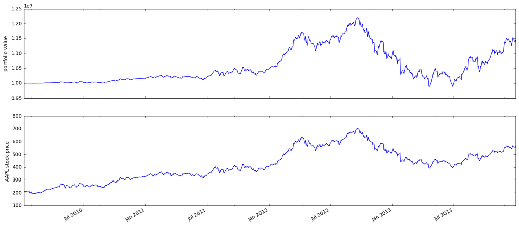

```python
%matplotlib inline
figsize(18, 8)

ax1 = plt.subplot(211)
perf.portfolio_value.plot(ax=ax1)
ax1.set_ylabel('portfolio value')
ax2 = plt.subplot(212, sharex=ax1)
perf.AAPL.plot(ax=ax2)
ax2.set_ylabel('AAPL stock price')
plt.show()
```

```python
# https://github.com/quantopian/zipline/tree/master/zipline/examples/buyapple.ipynb

%matplotlib inline
%load_ext zipline
```

```
The zipline extension is already loaded. To reload it, use:
  %reload_ext zipline
```

```
D:\Program Files\Anaconda3\lib\site-packages\pandas\tseries\index.py:755: PerformanceWarning: Non-vectorized DateOffset being applied to Series or DatetimeIndex
  PerformanceWarning)
```

```
[2016-11-13 14:13:41.375333] INFO: Performance: Simulated 502 trading days out of 502.
[2016-11-13 14:13:41.375833] INFO: Performance: first open: 2011-01-03 14:31:00+00:00
[2016-11-13 14:13:41.376334] INFO: Performance: last close: 2012-12-31 21:00:00+00:00
```

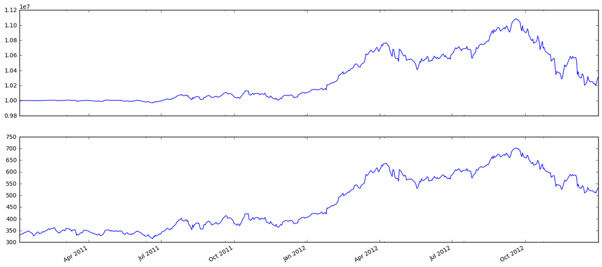

|  | AAPL | algo_volatility | algorithm_period_return | alpha | benchmark_period_return | benchmark_volatility | beta | capital_used | ending_cash | ending_exposure | ... | short_exposure | short_value | shorts_count | sortino | starting_cash | starting_exposure | starting_value | trading_days | transactions | treasury_period_return |
| --- | --- | --- | --- | --- | --- | --- | --- | --- | --- | --- | --- | --- | --- | --- | --- | --- | --- | --- | --- | --- | --- |
| 2011-01-03 21:00:00 | 329.570 | NaN | 0.000000e+00 | NaN | 0.011315 | NaN | NaN | 0.00 | 10000000.00 | 0.00 | ... | 0 | 0 | 0 | NaN | 10000000.00 | 0.00 | 0.00 | 1 | [] | 0.0336 |
| 2011-01-04 21:00:00 | 331.290 | 0.000001 | -1.000000e-07 | -0.000023 | 0.009987 | 0.141748 | 0.000008 | -3313.90 | 9996686.10 | 3312.90 | ... | 0 | 0 | 0 | -11.224972 | 10000000.00 | 0.00 | 0.00 | 2 | [{'sid': Equity(2686 [AAPL]), 'order_id': '30b... | 0.0336 |
| 2011-01-05 21:00:00 | 334.000 | 0.000024 | 2.510000e-06 | 0.000201 | 0.015044 | 0.100231 | 0.000008 | -3341.00 | 9993345.10 | 6680.00 | ... | 0 | 0 | 0 | 230.045324 | 9996686.10 | 3312.90 | 3312.90 | 3 | [{'sid': Equity(2686 [AAPL]), 'order_id': '132... | 0.0350 |
| 2011-01-06 21:00:00 | 333.730 | 0.000023 | 1.870000e-06 | 0.000059 | 0.012889 | 0.099481 | 0.000072 | -3338.30 | 9990006.80 | 10011.90 | ... | 0 | 0 | 0 | 22.913722 | 9993345.10 | 6680.00 | 6680.00 | 4 | [{'sid': Equity(2686 [AAPL]), 'order_id': 'e66... | 0.0344 |
| 2011-01-07 21:00:00 | 336.120 | 0.000051 | 8.940000e-06 | 0.000524 | 0.011021 | 0.093360 | -0.000132 | -3362.20 | 9986644.60 | 13444.80 | ... | 0 | 0 | 0 | 97.979577 | 9990006.80 | 10011.90 | 10011.90 | 5 | [{'sid': Equity(2686 [AAPL]), 'order_id': 'ccf... | 0.0334 |
| 2011-01-10 21:00:00 | 342.455 | 0.000159 | 3.418000e-05 | 0.001676 | 0.009629 | 0.086675 | -0.000592 | -3425.55 | 9983219.05 | 17122.75 | ... | 0 | 0 | 0 | 341.961345 | 9986644.60 | 13444.80 | 13444.80 | 6 | [{'sid': Equity(2686 [AAPL]), 'order_id': 'd79... | 0.0332 |
| 2011-01-11 21:00:00 | 341.640 | 0.000156 | 3.000500e-05 | 0.001415 | 0.013390 | 0.080133 | -0.000694 | -3417.40 | 9979801.65 | 20498.40 | ... | 0 | 0 | 0 | 42.612419 | 9983219.05 | 17122.75 | 17122.75 | 7 | [{'sid': Equity(2686 [AAPL]), 'order_id': '04a... | 0.0337 |
| 2011-01-12 21:00:00 | 344.420 | 0.000160 | 4.658500e-05 | 0.001574 | 0.022518 | 0.084200 | -0.000152 | -3445.20 | 9976356.45 | 24109.40 | ... | 0 | 0 | 0 | 61.885447 | 9979801.65 | 20498.40 | 20498.40 | 8 | [{'sid': Equity(2686 [AAPL]), 'order_id': '965... | 0.0340 |
| 2011-01-13 21:00:00 | 345.680 | 0.000151 | 5.530500e-05 | 0.001660 | 0.020769 | 0.082298 | -0.000193 | -3457.80 | 9972898.65 | 27654.40 | ... | 0 | 0 | 0 | 69.267298 | 9976356.45 | 24109.40 | 24109.40 | 9 | [{'sid': Equity(2686 [AAPL]), 'order_id': '047... | 0.0334 |
| 2011-01-14 21:00:00 | 348.480 | 0.000164 | 7.760500e-05 | 0.001859 | 0.028307 | 0.081684 | 0.000136 | -3485.80 | 9969412.85 | 31363.20 | ... | 0 | 0 | 0 | 92.208331 | 9972898.65 | 27654.40 | 27654.40 | 10 | [{'sid': Equity(2686 [AAPL]), 'order_id': '9c3... | 0.0335 |
| 2011-01-18 21:00:00 | 340.650 | 0.000406 | 7.035000e-06 | -0.000216 | 0.029722 | 0.077794 | 0.000559 | -3407.50 | 9966005.35 | 34065.00 | ... | 0 | 0 | 0 | 0.476546 | 9969412.85 | 31363.20 | 31363.20 | 11 | [{'sid': Equity(2686 [AAPL]), 'order_id': 'd7e... | 0.0339 |
| 2011-01-19 21:00:00 | 338.840 | 0.000396 | -1.116500e-05 | -0.000604 | 0.019306 | 0.094544 | 0.000911 | -3389.40 | 9962615.95 | 37272.40 | ... | 0 | 0 | 0 | -0.700708 | 9966005.35 | 34065.00 | 34065.00 | 12 | [{'sid': Equity(2686 [AAPL]), 'order_id': '832... | 0.0337 |
| 2011-01-20 21:00:00 | 332.680 | 0.000481 | -7.902500e-05 | -0.002002 | 0.017986 | 0.091418 | 0.001344 | -3327.80 | 9959288.15 | 39921.60 | ... | 0 | 0 | 0 | -3.490818 | 9962615.95 | 37272.40 | 37272.40 | 13 | [{'sid': Equity(2686 [AAPL]), 'order_id': '883... | 0.0347 |
| 2011-01-21 21:00:00 | 326.720 | 0.000539 | -1.506450e-04 | -0.003148 | 0.020443 | 0.087940 | 0.001184 | -3268.20 | 9956019.95 | 42473.60 | ... | 0 | 0 | 0 | -5.207546 | 9959288.15 | 39921.60 | 39921.60 | 14 | [{'sid': Equity(2686 [AAPL]), 'order_id': 'b2e... | 0.0344 |
| 2011-01-24 21:00:00 | 337.450 | 0.000805 | -1.125500e-05 | -0.001339 | 0.026399 | 0.086618 | 0.002605 | -3375.50 | 9952644.45 | 47243.00 | ... | 0 | 0 | 0 | -0.375267 | 9956019.95 | 42473.60 | 42473.60 | 15 | [{'sid': Equity(2686 [AAPL]), 'order_id': '444... | 0.0343 |
| 2011-01-25 21:00:00 | 341.400 | 0.000809 | 4.394500e-05 | -0.000313 | 0.026669 | 0.083889 | 0.002405 | -3415.00 | 9949229.45 | 51210.00 | ... | 0 | 0 | 0 | 1.421565 | 9952644.45 | 47243.00 | 47243.00 | 16 | [{'sid': Equity(2686 [AAPL]), 'order_id': 'c7f... | 0.0335 |
| 2011-01-26 21:00:00 | 343.850 | 0.000794 | 8.059500e-05 | 0.000026 | 0.031003 | 0.081822 | 0.002563 | -3439.50 | 9945789.95 | 55016.00 | ... | 0 | 0 | 0 | 2.528766 | 9949229.45 | 51210.00 | 51210.00 | 17 | [{'sid': Equity(2686 [AAPL]), 'order_id': '952... | 0.0345 |
| 2011-01-27 21:00:00 | 343.210 | 0.000773 | 7.025500e-05 | -0.000193 | 0.033316 | 0.079396 | 0.002547 | -3433.10 | 9942356.85 | 58345.70 | ... | 0 | 0 | 0 | 2.134760 | 9945789.95 | 55016.00 | 55016.00 | 18 | [{'sid': Equity(2686 [AAPL]), 'order_id': '6a5... | 0.0342 |
| 2011-01-28 21:00:00 | 336.100 | 0.000878 | -5.071500e-05 | -0.001538 | 0.014869 | 0.105327 | 0.004306 | -3362.00 | 9938994.85 | 60498.00 | ... | 0 | 0 | 0 | -1.069324 | 9942356.85 | 58345.70 | 58345.70 | 19 | [{'sid': Equity(2686 [AAPL]), 'order_id': '7a6... | 0.0336 |
| 2011-01-31 21:00:00 | 339.320 | 0.000881 | 7.145000e-06 | -0.001217 | 0.022646 | 0.105374 | 0.004547 | -3394.20 | 9935600.65 | 64470.80 | ... | 0 | 0 | 0 | 0.147515 | 9938994.85 | 60498.00 | 60498.00 | 20 | [{'sid': Equity(2686 [AAPL]), 'order_id': 'e19... | 0.0342 |
| 2011-02-01 21:00:00 | 345.030 | 0.000937 | 1.155350e-04 | -0.001015 | 0.039717 | 0.115978 | 0.005065 | -3451.30 | 9932149.35 | 69006.00 | ... | 0 | 0 | 0 | 2.318921 | 9935600.65 | 64470.80 | 64470.80 | 21 | [{'sid': Equity(2686 [AAPL]), 'order_id': 'efb... | 0.0348 |
| 2011-02-02 21:00:00 | 344.320 | 0.000917 | 1.012350e-04 | -0.000969 | 0.036887 | 0.114251 | 0.005050 | -3444.20 | 9928705.15 | 72307.20 | ... | 0 | 0 | 0 | 1.978514 | 9932149.35 | 69006.00 | 69006.00 | 22 | [{'sid': Equity(2686 [AAPL]), 'order_id': '274... | 0.0352 |
| 2011-02-03 21:00:00 | 343.440 | 0.000899 | 8.265500e-05 | -0.001254 | 0.039328 | 0.111647 | 0.005035 | -3435.40 | 9925269.75 | 75556.80 | ... | 0 | 0 | 0 | 1.571015 | 9928705.15 | 72307.20 | 72307.20 | 23 | [{'sid': Equity(2686 [AAPL]), 'order_id': '6b9... | 0.0358 |
| 2011-02-04 21:00:00 | 346.500 | 0.000903 | 1.498750e-04 | -0.000675 | 0.042325 | 0.109260 | 0.005094 | -3466.00 | 9921803.75 | 79695.00 | ... | 0 | 0 | 0 | 2.788093 | 9925269.75 | 75556.80 | 75556.80 | 24 | [{'sid': Equity(2686 [AAPL]), 'order_id': '745... | 0.0368 |
| 2011-02-07 21:00:00 | 351.880 | 0.000959 | 2.735150e-04 | 0.000099 | 0.048830 | 0.107905 | 0.005462 | -3519.80 | 9918283.95 | 84451.20 | ... | 0 | 0 | 0 | 4.984606 | 9921803.75 | 79695.00 | 79695.00 | 25 | [{'sid': Equity(2686 [AAPL]), 'order_id': '995... | 0.0368 |
| 2011-02-08 21:00:00 | 355.200 | 0.000964 | 3.530950e-04 | 0.000589 | 0.053219 | 0.105957 | 0.005571 | -3553.00 | 9914730.95 | 88800.00 | ... | 0 | 0 | 0 | 6.309501 | 9918283.95 | 84451.20 | 84451.20 | 26 | [{'sid': Equity(2686 [AAPL]), 'order_id': '634... | 0.0375 |
| 2011-02-09 21:00:00 | 358.160 | 0.000963 | 4.269950e-04 | 0.001566 | 0.050285 | 0.104931 | 0.005217 | -3582.60 | 9911148.35 | 93121.60 | ... | 0 | 0 | 0 | 7.486993 | 9914730.95 | 88800.00 | 88800.00 | 27 | [{'sid': Equity(2686 [AAPL]), 'order_id': '3cd... | 0.0365 |
| 2011-02-10 21:00:00 | 354.540 | 0.001001 | 3.327750e-04 | 0.000584 | 0.051072 | 0.103021 | 0.005313 | -3546.40 | 9907601.95 | 95725.80 | ... | 0 | 0 | 0 | 5.040908 | 9911148.35 | 93121.60 | 93121.60 | 28 | [{'sid': Equity(2686 [AAPL]), 'order_id': 'eea... | 0.0370 |
| 2011-02-11 21:00:00 | 356.850 | 0.000994 | 3.950450e-04 | 0.000804 | 0.056860 | 0.101753 | 0.005409 | -3569.50 | 9904032.45 | 99918.00 | ... | 0 | 0 | 0 | 5.879790 | 9907601.95 | 95725.80 | 95725.80 | 29 | [{'sid': Equity(2686 [AAPL]), 'order_id': '7d3... | 0.0364 |
| 2011-02-14 21:00:00 | 359.180 | 0.000988 | 4.601850e-04 | 0.001206 | 0.059381 | 0.099992 | 0.005427 | -3592.80 | 9900439.65 | 104162.20 | ... | 0 | 0 | 0 | 6.733874 | 9904032.45 | 99918.00 | 99918.00 | 30 | [{'sid': Equity(2686 [AAPL]), 'order_id': '0b6... | 0.0362 |
| ... | ... | ... | ... | ... | ... | ... | ... | ... | ... | ... | ... | ... | ... | ... | ... | ... | ... | ... | ... | ... | ... |
| 2012-11-16 21:00:00 | 527.678 | 0.040048 | 2.943771e-02 | 0.011145 | 0.081295 | 0.191082 | 0.085310 | -5277.78 | 7803736.93 | 2490640.16 | ... | 0 | 0 | 0 | 0.581207 | 7809014.71 | 2475670.20 | 2475670.20 | 473 | [{'sid': Equity(2686 [AAPL]), 'order_id': '0ac... | 0.0158 |
| 2012-11-19 21:00:00 | 565.730 | 0.041965 | 4.739815e-02 | 0.019182 | 0.102772 | 0.191416 | 0.089783 | -5658.30 | 7798078.63 | 2675902.90 | ... | 0 | 0 | 0 | 0.912542 | 7803736.93 | 2490640.16 | 2490640.16 | 474 | [{'sid': Equity(2686 [AAPL]), 'order_id': 'd64... | 0.0161 |
| 2012-11-20 21:00:00 | 560.913 | 0.041954 | 4.511961e-02 | 0.017957 | 0.103503 | 0.191214 | 0.089770 | -5610.13 | 7792468.50 | 2658727.62 | ... | 0 | 0 | 0 | 0.868836 | 7798078.63 | 2675902.90 | 2675902.90 | 475 | [{'sid': Equity(2686 [AAPL]), 'order_id': '7d3... | 0.0166 |
| 2012-11-21 21:00:00 | 561.700 | 0.041910 | 4.549255e-02 | 0.017997 | 0.106064 | 0.191018 | 0.089773 | -5618.00 | 7786850.50 | 2668075.00 | ... | 0 | 0 | 0 | 0.874687 | 7792468.50 | 2658727.62 | 2658727.62 | 476 | [{'sid': Equity(2686 [AAPL]), 'order_id': '763... | 0.0169 |
| 2012-11-23 18:00:00 | 571.500 | 0.041986 | 5.014745e-02 | 0.019648 | 0.120472 | 0.191042 | 0.090365 | -5716.00 | 7781134.50 | 2720340.00 | ... | 0 | 0 | 0 | 0.958079 | 7786850.50 | 2668075.00 | 2668075.00 | 477 | [{'sid': Equity(2686 [AAPL]), 'order_id': '641... | 0.0170 |
| 2012-11-26 21:00:00 | 589.530 | 0.042349 | 5.872963e-02 | 0.024033 | 0.118198 | 0.190850 | 0.090085 | -5896.30 | 7775238.20 | 2812058.10 | ... | 0 | 0 | 0 | 1.111665 | 7781134.50 | 2720340.00 | 2720340.00 | 478 | [{'sid': Equity(2686 [AAPL]), 'order_id': 'de2... | 0.0166 |
| 2012-11-27 21:00:00 | 584.780 | 0.042336 | 5.646378e-02 | 0.023094 | 0.112353 | 0.190692 | 0.090226 | -5848.80 | 7769389.40 | 2795248.40 | ... | 0 | 0 | 0 | 1.068403 | 7775238.20 | 2812058.10 | 2812058.10 | 479 | [{'sid': Equity(2686 [AAPL]), 'order_id': '2da... | 0.0164 |
| 2012-11-28 21:00:00 | 582.940 | 0.042297 | 5.558416e-02 | 0.022251 | 0.121092 | 0.190572 | 0.090047 | -5830.40 | 7763559.00 | 2792282.60 | ... | 0 | 0 | 0 | 1.051351 | 7769389.40 | 2795248.40 | 2795248.40 | 480 | [{'sid': Equity(2686 [AAPL]), 'order_id': 'fe2... | 0.0163 |
| 2012-11-29 21:00:00 | 589.360 | 0.042302 | 5.865924e-02 | 0.023518 | 0.125879 | 0.190395 | 0.090187 | -5894.60 | 7757664.40 | 2828928.00 | ... | 0 | 0 | 0 | 1.105093 | 7763559.00 | 2792282.60 | 2792282.60 | 481 | [{'sid': Equity(2686 [AAPL]), 'order_id': 'fb7... | 0.0162 |
| 2012-11-30 21:00:00 | 585.280 | 0.042282 | 5.670074e-02 | 0.022494 | 0.126062 | 0.190197 | 0.090191 | -5853.80 | 7751810.60 | 2815196.80 | ... | 0 | 0 | 0 | 1.067924 | 7757664.40 | 2828928.00 | 2828928.00 | 482 | [{'sid': Equity(2686 [AAPL]), 'order_id': '08d... | 0.0162 |
| 2012-12-03 21:00:00 | 586.190 | 0.042239 | 5.713835e-02 | 0.022891 | 0.120718 | 0.190034 | 0.090136 | -5862.90 | 7745947.70 | 2825435.80 | ... | 0 | 0 | 0 | 1.074588 | 7751810.60 | 2815196.80 | 2815196.80 | 483 | [{'sid': Equity(2686 [AAPL]), 'order_id': '2c0... | 0.0163 |
| 2012-12-04 21:00:00 | 575.845 | 0.042339 | 5.215196e-02 | 0.020458 | 0.118802 | 0.189843 | 0.090272 | -5759.45 | 7740188.25 | 2781331.35 | ... | 0 | 0 | 0 | 0.977756 | 7745947.70 | 2825435.80 | 2825435.80 | 484 | [{'sid': Equity(2686 [AAPL]), 'order_id': 'db2... | 0.0162 |
| 2012-12-05 21:00:00 | 538.792 | 0.044058 | 3.425526e-02 | 0.011528 | 0.120575 | 0.189649 | 0.089953 | -5388.92 | 7734799.33 | 2607753.28 | ... | 0 | 0 | 0 | 0.605002 | 7740188.25 | 2781331.35 | 2781331.35 | 485 | [{'sid': Equity(2686 [AAPL]), 'order_id': '30f... | 0.0160 |
| 2012-12-06 21:00:00 | 547.244 | 0.044101 | 3.834593e-02 | 0.013389 | 0.124280 | 0.189466 | 0.090110 | -5473.44 | 7729325.89 | 2654133.40 | ... | 0 | 0 | 0 | 0.671627 | 7734799.33 | 2607753.28 | 2607753.28 | 486 | [{'sid': Equity(2686 [AAPL]), 'order_id': 'af8... | 0.0159 |
| 2012-12-07 21:00:00 | 533.250 | 0.044312 | 3.155874e-02 | 0.009863 | 0.127564 | 0.189280 | 0.089851 | -5333.50 | 7723992.39 | 2591595.00 | ... | 0 | 0 | 0 | 0.553361 | 7729325.89 | 2654133.40 | 2654133.40 | 487 | [{'sid': Equity(2686 [AAPL]), 'order_id': 'dad... | 0.0164 |
| 2012-12-10 21:00:00 | 529.820 | 0.044284 | 2.989166e-02 | 0.008993 | 0.127946 | 0.189086 | 0.089851 | -5299.20 | 7718693.19 | 2580223.40 | ... | 0 | 0 | 0 | 0.525320 | 7723992.39 | 2591595.00 | 2591595.00 | 488 | [{'sid': Equity(2686 [AAPL]), 'order_id': 'b9c... | 0.0163 |
| 2012-12-11 21:00:00 | 541.388 | 0.044408 | 3.552517e-02 | 0.011454 | 0.135333 | 0.188945 | 0.090287 | -5414.88 | 7713278.31 | 2641973.44 | ... | 0 | 0 | 0 | 0.616351 | 7718693.19 | 2580223.40 | 2580223.40 | 489 | [{'sid': Equity(2686 [AAPL]), 'order_id': '91a... | 0.0166 |
| 2012-12-12 21:00:00 | 539.000 | 0.044371 | 3.435973e-02 | 0.010831 | 0.135842 | 0.188752 | 0.090285 | -5391.00 | 7707887.31 | 2635710.00 | ... | 0 | 0 | 0 | 0.596696 | 7713278.31 | 2641973.44 | 2641973.44 | 490 | [{'sid': Equity(2686 [AAPL]), 'order_id': 'a3b... | 0.0172 |
| 2012-12-13 21:00:00 | 529.690 | 0.044441 | 2.980704e-02 | 0.008813 | 0.128662 | 0.188619 | 0.090656 | -5297.90 | 7702589.41 | 2595481.00 | ... | 0 | 0 | 0 | 0.519853 | 7707887.31 | 2635710.00 | 2635710.00 | 491 | [{'sid': Equity(2686 [AAPL]), 'order_id': 'faf... | 0.0174 |
| 2012-12-14 21:00:00 | 509.794 | 0.044917 | 2.005790e-02 | 0.004093 | 0.123994 | 0.188454 | 0.091242 | -5098.94 | 7697490.47 | 2503088.54 | ... | 0 | 0 | 0 | 0.353785 | 7702589.41 | 2595481.00 | 2595481.00 | 492 | [{'sid': Equity(2686 [AAPL]), 'order_id': 'd21... | 0.0172 |
| 2012-12-17 21:00:00 | 518.830 | 0.044977 | 2.449448e-02 | 0.005709 | 0.137337 | 0.188444 | 0.091783 | -5189.30 | 7692301.17 | 2552643.60 | ... | 0 | 0 | 0 | 0.423858 | 7697490.47 | 2503088.54 | 2503088.54 | 493 | [{'sid': Equity(2686 [AAPL]), 'order_id': '4b2... | 0.0178 |
| 2012-12-18 21:00:00 | 533.900 | 0.045223 | 3.190882e-02 | 0.008763 | 0.150401 | 0.188421 | 0.092771 | -5340.00 | 7686961.17 | 2632127.00 | ... | 0 | 0 | 0 | 0.540504 | 7692301.17 | 2552643.60 | 2552643.60 | 494 | [{'sid': Equity(2686 [AAPL]), 'order_id': '024... | 0.0184 |
| 2012-12-19 21:00:00 | 526.310 | 0.045254 | 2.816685e-02 | 0.007229 | 0.141670 | 0.188315 | 0.093108 | -5264.10 | 7681697.07 | 2599971.40 | ... | 0 | 0 | 0 | 0.479739 | 7686961.17 | 2632127.00 | 2632127.00 | 495 | [{'sid': Equity(2686 [AAPL]), 'order_id': '63c... | 0.0182 |
| 2012-12-20 21:00:00 | 521.730 | 0.045237 | 2.590423e-02 | 0.005855 | 0.147936 | 0.188161 | 0.092905 | -5218.30 | 7676478.77 | 2582563.50 | ... | 0 | 0 | 0 | 0.443299 | 7681697.07 | 2599971.40 | 2599971.40 | 496 | [{'sid': Equity(2686 [AAPL]), 'order_id': '6fa... | 0.0181 |
| 2012-12-21 21:00:00 | 519.330 | 0.045200 | 2.471613e-02 | 0.005694 | 0.137170 | 0.188099 | 0.092949 | -5194.30 | 7671284.47 | 2575876.80 | ... | 0 | 0 | 0 | 0.424116 | 7676478.77 | 2582563.50 | 2582563.50 | 497 | [{'sid': Equity(2686 [AAPL]), 'order_id': '2b3... | 0.0177 |
| 2012-12-24 18:00:00 | 520.168 | 0.045155 | 2.513167e-02 | 0.006004 | 0.134395 | 0.187920 | 0.092924 | -5202.68 | 7666081.79 | 2585234.96 | ... | 0 | 0 | 0 | 0.430192 | 7671284.47 | 2575876.80 | 2575876.80 | 498 | [{'sid': Equity(2686 [AAPL]), 'order_id': '6e8... | 0.0179 |
| 2012-12-26 21:00:00 | 512.999 | 0.045179 | 2.156858e-02 | 0.004444 | 0.128964 | 0.187766 | 0.093148 | -5130.99 | 7660950.80 | 2554735.02 | ... | 0 | 0 | 0 | 0.372948 | 7666081.79 | 2585234.96 | 2585234.96 | 499 | [{'sid': Equity(2686 [AAPL]), 'order_id': '3a4... | 0.0177 |
| 2012-12-27 21:00:00 | 515.059 | 0.045139 | 2.259436e-02 | 0.005000 | 0.127588 | 0.187581 | 0.093124 | -5151.59 | 7655799.21 | 2570144.41 | ... | 0 | 0 | 0 | 0.388592 | 7660950.80 | 2554735.02 | 2554735.02 | 500 | [{'sid': Equity(2686 [AAPL]), 'order_id': '523... | 0.0174 |
| 2012-12-28 21:00:00 | 509.589 | 0.045135 | 1.986473e-02 | 0.004146 | 0.115128 | 0.187566 | 0.093394 | -5096.89 | 7650702.32 | 2547945.00 | ... | 0 | 0 | 0 | 0.345046 | 7655799.21 | 2570144.41 | 2570144.41 | 501 | [{'sid': Equity(2686 [AAPL]), 'order_id': '385... | 0.0173 |
| 2012-12-31 21:00:00 | 532.172 | 0.045762 | 3.115613e-02 | 0.008719 | 0.134021 | 0.187750 | 0.095640 | -5322.72 | 7645379.60 | 2666181.72 | ... | 0 | 0 | 0 | 0.520644 | 7650702.32 | 2547945.00 | 2547945.00 | 502 | [{'sid': Equity(2686 [AAPL]), 'order_id': 'd22... | 0.0178 |

502 rows × 39 columns

```python
%%zipline --start=2011-1-1 --end=2013-1-1

from zipline.api import order, record, symbol
import matplotlib.pyplot as plt

def initialize(context):
    pass

def handle_data(context, data):
    order(symbol('AAPL'), 10)
    record(AAPL=data[symbol('AAPL')].price)

def analyze(context, perf):
    ax1 = plt.subplot(211)
    perf.portfolio_value.plot(ax=ax1)
    ax2 = plt.subplot(212, sharex=ax1)
    perf.AAPL.plot(ax=ax2)
    plt.gcf().set_size_inches(18, 8)
    plt.show()
```

# 實例演練：zipline

- 範例來源：
  - [zpline: eamples](https://github.com/quantopian/zipline/tree/master/zipline/examples)
  - [Quantopian Search: Menu => Community => Forum => Search => Clone Notebook](https://www.quantopian.com/posts)
  - [Quantopian Overview: Sample Algorithms](https://www.quantopian.com/help#sample-algos)
- 疑難排除：
  - http://www.zipline.io/